# Relationship between Marital Status and LDL

```r
library(olsrr)
library(nhanesA)
library(knitr);
library(rmdformats)
library(janitor);
library(magrittr);
library(naniar)
library(broom);
library(patchwork)
library(GGally)
library(rmarkdown)
library(mosaic)
library(readxl)
library(Epi)
library(car)
library(equatiomatic)
library(janitor)
library(naniar)
library(simputation)
library(broom)
library(Hmisc)
library(tidyverse)

source("Love-boost.R")

## Global options
opts_chunk$set(comment=NA)
opts_knit$set(width=75)
theme_set(theme_bw())
```

# 1 Setup and Data Ingest

## 1.1 Ingest the data

Here we have ingested the raw data files from NHANES. Five NHANES databases that we used are:

- Demographics (DEMO_J) : Demographic Variables and Sample Weights
- Questionnaire (CDQ_J) : Cardiovascular Health
- Laboratory (TRIGLY_J) : Cholesterol - Low-Density Lipoproteins (LDL) & Triglycerides
- Examination (BPX_J): Blood Pressure
- Questionnaire (DBQ_J): Diet Behavior & Nutrition

```r
demo_raw <- nhanes('DEMO_J') %>% tibble()
```

```
Processing SAS dataset DEMO_J    ..
```

```r
cdq_raw <- nhanes('CDQ_J') %>% tibble()
```

```
Processing SAS dataset CDQ_J     ..
```

```r
bpx_raw <- nhanes('TRIGLY_J') %>% tibble()
```

```
Processing SAS dataset TRIGLY_J      ..
```

```r
exam_raw <- nhanes('BPX_J') %>% tibble()
```

```
Processing SAS dataset BPX_J     ..
```

```r
diet_raw <- nhanes('DBQ_J') %>% tibble()
```

```
Processing SAS dataset DBQ_J     ..
```

# 2 Cleaning the Data

In the next few steps, we selected the variables that we will be using for our analysis. We filtered these variables based on complete cases.

These variables are: From Questionnaire (DBQ_J), we want the following variables.

- DBD895 : # of meals not home prepared [ignore 7777, 9999]

```r
diet_data <- diet_raw %>%
    select(SEQN, DBD895) %>%
    filter(complete.cases(.))

dim(diet_data) #no of observations
```

```
[1] 8838    2
```

From Demographics, we want the following variables. Further we limited the data for age between 20 and 80 years. We did this because marital status data, which is our key predictor is available for only age 20 and above.

- SEQN : Respondent sequence number
- RIAGENDR : Gender
- RIDAGEYR : Age in years at screening
- RIDRETH1 : Race/Hispanic origin
- DMDMARTL : Marital status (key predictor) [77, 99]

```r
demo_data <- demo_raw %>%
    select(SEQN, RIAGENDR, RIDAGEYR, RIDRETH1, DMDMARTL) %>%
    filter (RIDAGEYR >= 20 & RIDAGEYR <= 80) %>%
    filter(complete.cases(.))

dim(demo_data) #no of observations
```

```
[1] 5569    5
```

From Cardiovascular Health (CDQ_J) we selected shortness of breath as the variable to assess physical health

- SEQN : Respondent sequence number
- CDQ010 - Shortness of breath on stairs/inclines [9:Don’t Know]

```r
cdq_data <- cdq_raw %>%
    select(SEQN, CDQ010) %>%
    filter(complete.cases(.))

dim(cdq_data) #no of observations
```

```
[1] 3882    2
```

From Lab (TRIGLY_J), we selected the following variables. (filtered for 20 and above)

- SEQN : Respondent sequence number
- LBDLDL : LDL-Cholesterol, Friedewald (mg/dL) (outcome)

```r
bpx_data <- bpx_raw %>%
    select(SEQN, LBDLDL ) %>%
    filter(complete.cases(.))

dim(bpx_data) #no of observations
```

```
[1] 2808    2
```

```r
bpx_data
```

| SEQN | LBDLDL |
| --- | --- |
| 93708 | 109 |
| 93711 | 156 |
| 93717 | 140 |
| 93718 | 80 |
| 93719 | 35 |
| 93721 | 61 |
| 93722 | 95 |
| 93731 | 97 |
| 93735 | 56 |
| 93738 | 89 |

[output cut: 2798 more lines]

From Exam (BPX_J), I want the following variables.

- SEQN : Respondent sequence number
- BPXSY1 : Systolic: Blood pres (1st rdg) mm Hg
- BPXDI1 : Diastolic: Blood pres (1st rdg) mm Hg
- BPXSY2:Systolic: Blood pres (2nd rdg) mm Hg

```r
exam_data <- exam_raw %>%
    select(SEQN, BPXSY1, BPXDI1, BPXSY2) %>%
    filter(complete.cases(.))

dim(exam_data) #no of observations
```

```
[1] 6187    4
```

## 2.1 Merging the Data

```r
temp1 <- left_join(demo_data, cdq_data, by = "SEQN")
temp2 <- left_join(temp1, bpx_data, by = "SEQN")
temp3 <- left_join(temp2, exam_data, by = "SEQN")
merged_data <- left_join(temp3, diet_data, by = "SEQN") %>%  filter(complete.cases(.))

dim(merged_data)
```

```
[1] 1430   11
```

```r
merged_data
```

| SEQN | RIAGENDR | RIDAGEYR | RIDRETH1 | DMDMARTL | CDQ010 | LBDLDL | BPXSY1 | BPXDI1 | BPXSY2 | DBD895 |
| --- | --- | --- | --- | --- | --- | --- | --- | --- | --- | --- |
| 93711 | 1 | 56 | 5 | 1 | 2 | 156 | 108 | 68 | 94 | 4 |
| 93718 | 1 | 45 | 4 | 5 | 2 | 80 | 128 | 88 | 136 | 2 |
| 93721 | 2 | 60 | 1 | 1 | 2 | 61 | 132 | 68 | 136 | 1 |
| 93722 | 2 | 60 | 3 | 3 | 2 | 95 | 116 | 68 | 110 | 7 |
| 93735 | 1 | 52 | 2 | 1 | 1 | 56 | 154 | 74 | 156 | 1 |
| 93742 | 1 | 72 | 4 | 2 | 1 | 91 | 166 | 90 | 170 | 3 |
| 93752 | 2 | 73 | 3 | 2 | 2 | 165 | 126 | 60 | 130 | 1 |
| 93758 | 2 | 55 | 3 | 1 | 1 | 354 | 154 | 74 | 154 | 0 |
| 93759 | 1 | 60 | 5 | 1 | 1 | 25 | 118 | 64 | 116 | 2 |
| 93760 | 2 | 54 | 1 | 5 | 2 | 137 | 132 | 66 | 134 | 0 |

[output cut: 1420 more lines]

```r
dim(merged_data)
```

```
[1] 1430   11
```

```r
mydata <- merged_data %>%
    mutate(DMDMARTL = na_if(DMDMARTL, "77"),
           DMDMARTL = na_if(DMDMARTL, "99"),
           CDQ010 = na_if(CDQ010, "9"),
           DBD895 = na_if(DBD895, "9999"),
           DBD895 = na_if(DBD895, "5555"),
           DBD895 = na_if(DBD895, "7777")) %>%
    filter(complete.cases(.)) %>%
    mutate(RIAGENDR = factor(RIAGENDR),
           RIDRETH1 = factor(RIDRETH1),
           DMDMARTL = factor(DMDMARTL),
           CDQ010 = factor(CDQ010),

           DBD895 = as.numeric(DBD895),
           SEQN = as.numeric(SEQN),
           RIDAGEYR = as.numeric(RIDAGEYR),
           LBDLDL = as.numeric(LBDLDL),
           BPXSY1 = as.numeric(BPXSY1),
           BPXDI1 = as.numeric(BPXDI1),
           BPXSY2 = as.numeric(BPXSY2)) %>%

    rename(gender = RIAGENDR,
           age = RIDAGEYR,
           race = RIDRETH1,
           marital_status = DMDMARTL,
           shortness_of_breath = CDQ010,
           ldl_chol = LBDLDL,
           sbp  = BPXSY1,
           dbp  = BPXDI1,
           sbp2 = BPXSY2,
           no_of_meals_not_homeprepared = DBD895 )

dim(mydata)
```

```
[1] 1418   11
```

## 2.2 The Raw Data

```r
glimpse(mydata)
```

```
Rows: 1,418
Columns: 11
$ SEQN                         <dbl> 93711, 93718, 93721, 93722, 93735, 93742,~
$ gender                       <fct> 1, 1, 2, 2, 1, 1, 2, 2, 1, 2, 2, 1, 1, 2,~
$ age                          <dbl> 56, 45, 60, 60, 52, 72, 73, 55, 60, 54, 7~
$ race                         <fct> 5, 4, 1, 3, 2, 4, 3, 3, 5, 1, 1, 3, 2, 4,~
$ marital_status               <fct> 1, 5, 1, 3, 1, 2, 2, 1, 1, 5, 2, 1, 5, 5,~
$ shortness_of_breath          <fct> 2, 2, 2, 2, 1, 1, 2, 1, 1, 2, 2, 1, 2, 2,~
$ ldl_chol                     <dbl> 156, 80, 61, 95, 56, 91, 165, 354, 25, 13~
$ sbp                          <dbl> 108, 128, 132, 116, 154, 166, 126, 154, 1~
$ dbp                          <dbl> 68, 88, 68, 68, 74, 90, 60, 74, 64, 66, 6~
$ sbp2                         <dbl> 94, 136, 136, 110, 156, 170, 130, 154, 11~
$ no_of_meals_not_homeprepared <dbl> 4, 2, 1, 7, 1, 3, 1, 0, 2, 0, 1, 3, 1, 0,~
```

## 2.3 Checking the Categorical Variables

```r
mydata %>% tabyl(gender)
```

| gender | n | percent |
| --- | --- | --- |
| 1 | 706 | 0.4978843 |
| 2 | 712 | 0.5021157 |

```r
mydata <- mydata %>%
  mutate(gender = fct_recode(gender, Male = '1', Female = '2'))
```

```r
mydata %>% tabyl(race)
```

| race | n | percent |
| --- | --- | --- |
| 1 | 196 | 0.13822285 |
| 2 | 133 | 0.09379408 |
| 3 | 494 | 0.34837800 |
| 4 | 315 | 0.22214386 |
| 5 | 280 | 0.19746121 |

```r
mydata <- mydata %>%
  mutate(race = fct_recode(race, Mexican_American = '1', Other_Hispanic = '2', Non_Hispanic_White = '3', Non_Hispanic_Black = '4', Other_Race = '5'))
```

```r
mydata %>% tabyl(marital_status)
```

| marital_status | n | percent |
| --- | --- | --- |
| 1 | 813 | 0.57334274 |
| 2 | 145 | 0.10225670 |
| 3 | 219 | 0.15444288 |
| 4 | 48 | 0.03385049 |
| 5 | 109 | 0.07686883 |
| 6 | 84 | 0.05923836 |

```r
mydata <- mydata %>%
  mutate(marital_status = fct_recode(marital_status, Married = '1', Widowed = '2', Divorced = '3', Separated = '4', Never_married = '5', Living_with_partner = '6'))
```

```r
mydata %>% tabyl(shortness_of_breath)
```

| shortness_of_breath | n | percent |
| --- | --- | --- |
| 1 | 525 | 0.3702398 |
| 2 | 893 | 0.6297602 |

```r
mydata <- mydata %>%
  mutate(shortness_of_breath = fct_recode(shortness_of_breath, Yes = '1', No = '2'))
```

```r
glimpse(mydata)
```

```
Rows: 1,418
Columns: 11
$ SEQN                         <dbl> 93711, 93718, 93721, 93722, 93735, 93742,~
$ gender                       <fct> Male, Male, Female, Female, Male, Male, F~
$ age                          <dbl> 56, 45, 60, 60, 52, 72, 73, 55, 60, 54, 7~
$ race                         <fct> Other_Race, Non_Hispanic_Black, Mexican_A~
$ marital_status               <fct> Married, Never_married, Married, Divorced~
$ shortness_of_breath          <fct> No, No, No, No, Yes, Yes, No, Yes, Yes, N~
$ ldl_chol                     <dbl> 156, 80, 61, 95, 56, 91, 165, 354, 25, 13~
$ sbp                          <dbl> 108, 128, 132, 116, 154, 166, 126, 154, 1~
$ dbp                          <dbl> 68, 88, 68, 68, 74, 90, 60, 74, 64, 66, 6~
$ sbp2                         <dbl> 94, 136, 136, 110, 156, 170, 130, 154, 11~
$ no_of_meals_not_homeprepared <dbl> 4, 2, 1, 7, 1, 3, 1, 0, 2, 0, 1, 3, 1, 0,~
```

## 2.4 No of Subjects

```r
nrow(mydata)
```

```
[1] 1418
```

```r
n_distinct(mydata %>% select(SEQN))
```

```
[1] 1418
```

## 2.5 The Complete Cases Tibble

```r
mydata
```

| SEQN | gender | age | race | marital_status | shortness_of_breath | ldl_chol | sbp | dbp | sbp2 | no_of_meals_not_homeprepared |
| --- | --- | --- | --- | --- | --- | --- | --- | --- | --- | --- |
| 93711 | Male | 56 | Other_Race | Married | No | 156 | 108 | 68 | 94 | 4 |
| 93718 | Male | 45 | Non_Hispanic_Black | Never_married | No | 80 | 128 | 88 | 136 | 2 |
| 93721 | Female | 60 | Mexican_American | Married | No | 61 | 132 | 68 | 136 | 1 |
| 93722 | Female | 60 | Non_Hispanic_White | Divorced | No | 95 | 116 | 68 | 110 | 7 |
| 93735 | Male | 52 | Other_Hispanic | Married | Yes | 56 | 154 | 74 | 156 | 1 |
| 93742 | Male | 72 | Non_Hispanic_Black | Widowed | Yes | 91 | 166 | 90 | 170 | 3 |
| 93752 | Female | 73 | Non_Hispanic_White | Widowed | No | 165 | 126 | 60 | 130 | 1 |
| 93758 | Female | 55 | Non_Hispanic_White | Married | Yes | 354 | 154 | 74 | 154 | 0 |
| 93759 | Male | 60 | Other_Race | Married | Yes | 25 | 118 | 64 | 116 | 2 |
| 93760 | Female | 54 | Mexican_American | Never_married | No | 137 | 132 | 66 | 134 | 0 |

[output cut: 1408 more lines]

```r
describe(mydata)
```

```
mydata

 11  Variables      1418  Observations
--------------------------------------------------------------------------------
SEQN
       n  missing distinct     Info     Mean      Gmd      .05      .10
    1418        0     1418        1    98375     3132    94141    94633
     .25      .50      .75      .90      .95
   96048    98361   100778   102124   102591

lowest :  93711  93718  93721  93722  93735, highest: 102920 102929 102947 102952 102954
--------------------------------------------------------------------------------
gender
       n  missing distinct
    1418        0        2

Value        Male Female
Frequency     706    712
Proportion  0.498  0.502
--------------------------------------------------------------------------------
age
       n  missing distinct     Info     Mean      Gmd      .05      .10
    1418        0       41    0.998     60.8    13.43       42       45
     .25      .50      .75      .90      .95
      52       61       70       79       80

lowest : 40 41 42 43 44, highest: 76 77 78 79 80
--------------------------------------------------------------------------------
race
       n  missing distinct
    1418        0        5

lowest : Mexican_American   Other_Hispanic     Non_Hispanic_White Non_Hispanic_Black Other_Race
highest: Mexican_American   Other_Hispanic     Non_Hispanic_White Non_Hispanic_Black Other_Race

Value        Mexican_American     Other_Hispanic Non_Hispanic_White
Frequency                 196                133                494
Proportion              0.138              0.094              0.348

Value      Non_Hispanic_Black         Other_Race
```

[output cut: 59 more lines]

```
       n  missing distinct     Info     Mean      Gmd      .05      .10
    1418        0       20    0.968     2.75    3.214        0        0
     .25      .50      .75      .90      .95
       0        2        4        7       10

lowest :  0  1  2  3  4, highest: 16 18 19 20 21

Value          0     1     2     3     4     5     6     7     8     9    10
Frequency    369   268   241   177    97    83    29    48    11     6    32
Proportion 0.260 0.189 0.170 0.125 0.068 0.059 0.020 0.034 0.008 0.004 0.023

Value         11    12    14    15    16    18    19    20    21
Frequency      2    11    20    11     3     3     1     2     4
Proportion 0.001 0.008 0.014 0.008 0.002 0.002 0.001 0.001 0.003
--------------------------------------------------------------------------------
```

## 2.6 Checking our Outcome and Key Predictor

```r
df_stats(~ marital_status + ldl_chol, data = mydata)
```

| response | min | Q1 | median | Q3 | max | mean | sd | n | missing |
| --- | --- | --- | --- | --- | --- | --- | --- | --- | --- |
| marital_status | 1 | 1 | 1 | 3 | 6 | 2.116361 | 1.578302 | 1418 | 0 |
| ldl_chol | 18 | 87 | 110 | 136 | 357 | 112.363893 | 38.410977 | 1418 | 0 |

## 2.7 Checking the Quantitative Predictors

```r
df_stats(~ age + ldl_chol + sbp + dbp + sbp2 + no_of_meals_not_homeprepared, data = mydata)
```

| response | min | Q1 | median | Q3 | max | mean | sd | n | missing |
| --- | --- | --- | --- | --- | --- | --- | --- | --- | --- |
| age | 40 | 52 | 61 | 70 | 80 | 60.799013 | 11.670667 | 1418 | 0 |
| ldl_chol | 18 | 87 | 110 | 136 | 357 | 112.363893 | 38.410977 | 1418 | 0 |
| sbp | 78 | 116 | 128 | 142 | 228 | 131.166432 | 20.852724 | 1418 | 0 |
| dbp | 0 | 66 | 74 | 80 | 124 | 72.866008 | 13.413792 | 1418 | 0 |
| sbp2 | 72 | 116 | 128 | 142 | 228 | 130.832158 | 20.849057 | 1418 | 0 |
| no_of_meals_not_homeprepared | 0 | 0 | 2 | 4 | 21 | 2.750353 | 3.401775 | 1418 | 0 |

# 3 Codebook and Data Description

## 3.1 Codebook

This is a table listing all 11 variables that are included in our tibble, and providing some important information about them.

[output not shown]

# 4 Analysis A:Compare 2 Population Means using Paired Samples

## 4.1 Research question

What is the relationship between the mean systolic blood pressure(sbp) at first reading and mean systolic blood pressure of the same subject at second reading (sbp2)?

## 4.2 Creating dataset

```r
mydata_a<-mydata %>%
    select(sbp,sbp2)%>%
  mutate(bpdiff=sbp-sbp2)%>%
  mutate(pairs=row(.))


mydata_afinal<-mydata_a%>%
    pivot_longer(
        cols = -c(pairs),
        names_to = "BPtype",
        values_to = "BP")

favstats(~BP,BPtype,data=mydata_afinal)
```

| BPtype | min | Q1 | median | Q3 | max | mean | sd | n | missing |
| --- | --- | --- | --- | --- | --- | --- | --- | --- | --- |
| bpdiff | -22 | -4 | 0 | 4 | 20 | 0.3342736 | 5.432693 | 1418 | 0 |
| sbp | 78 | 116 | 128 | 142 | 228 | 131.1664316 | 20.852724 | 1418 | 0 |
| sbp2 | 72 | 116 | 128 | 142 | 228 | 130.8321580 | 20.849057 | 1418 | 0 |

## 4.3 Describing the data

Upon checking distribution of the difference in mean SBP, we see that the histogram shows normal distribution. There are multiple outliers noted on both sides of the distribution, but the data appears to be normally distributed without significant skew. The mean SBP at first reading is 131.1 with a SD of 20.8 and the mean SBP at second reading was 130.8 with a SD of 20.8 as well.

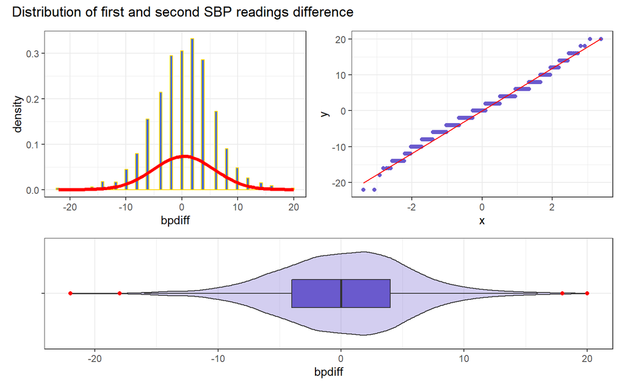

```r
p1<-ggplot(data=mydata_a,aes(bpdiff))+
  geom_histogram(aes(y=..density..),bins=90, fill = "royalblue",col = "gold")+
  stat_function(fun = dnorm,
                args = list(mean = mean(mydata_a$bpdiff), sd = sd(mydata_a$bpdiff)),
                col="red",lwd=1.5)+
  theme_bw()

p2 <- ggplot(mydata_a, aes(sample = bpdiff)) +
  geom_qq(col = "slateblue") + geom_qq_line(col = "red")

p3 <- ggplot(mydata_a, aes(x = "", y = bpdiff)) +
  geom_violin(fill = "slateblue", alpha = 0.3) +
  geom_boxplot(fill = "slateblue", width = 0.3,
               outlier.color = "red") +
  labs(x = "") + coord_flip()

 p1 + p2 - p3 +
  plot_layout(ncol = 1, height = c(3, 2)) +
  plot_annotation(title = "Distribution of first and second SBP readings difference")
```

Since the data is normally distributed, paired t-test is appropriate

```r
mydata_a%$%t.test(bpdiff,conf.level=0.90)
```

```
    One Sample t-test

data:  bpdiff
t = 2.317, df = 1417, p-value = 0.02065
alternative hypothesis: true mean is not equal to 0
90 percent confidence interval:
 0.0968148 0.5717325
sample estimates:
mean of x
0.3342736
```

## 4.4 Conclusion

There is a very small difference of 0.33 mmHg with a 90% CI of 0.09-0.57 between the first and the second reading of systolic blood pressure which is statistically significant. However this small value is not clinically relevant or significant.

# 5 Analysis B: Compare 2 Population Means using Independent Samples

## 5.1 Reasearch Question

Is there a difference in average age between males and females in our study sample?

## 5.2 Creating dataset

Here we have created another tibble called “mydata_b” with only the variables needed for this analysis.

```r
mydata_b<-mydata%>%
  select(age,gender)
str(mydata_b)
```

```
tibble [1,418 x 2] (S3: tbl_df/tbl/data.frame)
 $ age   : num [1:1418] 56 45 60 60 52 72 73 55 60 54 ...
 $ gender: Factor w/ 2 levels "Male","Female": 1 1 2 2 1 1 2 2 1 2 ...
```

## 5.3 Describing the data

Upon checking distribution of the variable “age” in both the groups, we see that it is skewed. However, the variance between groups appears to be similar. Since the outcome was not normally distributed, we elected to do a bootstrap method to compare the mean age between males and females.

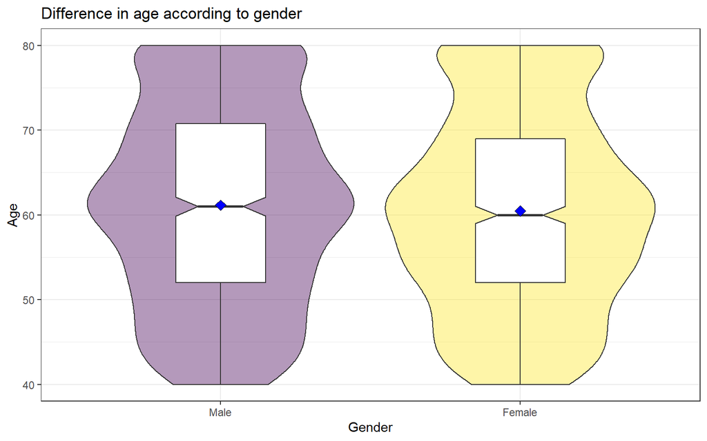

```r
 ggplot(mydata_b, aes(x = age, y = gender)) +
  geom_violin(aes(fill = gender)) +
  geom_boxplot(width = 0.3, outlier.size = 2, notch = T) +
  stat_summary(fun = "mean", geom = "point",
               shape = 23, size = 3, fill = "blue") +
  guides(fill = "none") +
  scale_fill_viridis_d(alpha = 0.4) +
  coord_flip() +
  labs(y = "Gender",
       x = "Age",
       title = "Difference in age according to gender")
```

```r
favstats(~age,gender,data=mydata_b)
```

| gender | min | Q1 | median | Q3 | max | mean | sd | n | missing |
| --- | --- | --- | --- | --- | --- | --- | --- | --- | --- |
| Male | 40 | 52 | 61 | 70.75 | 80 | 61.14873 | 11.72458 | 706 | 0 |
| Female | 40 | 52 | 60 | 69.00 | 80 | 60.45225 | 11.61480 | 712 | 0 |

## 5.4 Main Analysis

We decided to use the bootstrap method because we were not convinced that the sample was uniformly distributed.

```r
set.seed(431)
mydata_b%$% bootdif(y = age, g = gender, conf.level = 0.90)
```

```
Mean Difference            0.05            0.95
     -0.6964780      -1.6731087       0.3032486
```

# 6 Analysis C: Comparing 3+ Population Means via ANOVA

## 6.1 Research question

Is the mean ldl value different across the race in our sample? For analysis C, our quantitative outcome is ldl and our categorical predictor is race.

## 6.2 Creating dataset

Here we have created a tibble called “mydata_c” with only the variables required for this analysis.

```r
mydata_c<-mydata%>%
  select(ldl_chol,race)
str(mydata_c)
```

```
tibble [1,418 x 2] (S3: tbl_df/tbl/data.frame)
 $ ldl_chol: num [1:1418] 156 80 61 95 56 91 165 354 25 137 ...
 $ race    : Factor w/ 5 levels "Mexican_American",..: 5 4 1 3 2 4 3 3 5 1 ...
```

```r
favstats(~ldl_chol,race,data=mydata_c)
```

| race | min | Q1 | median | Q3 | max | mean | sd | n | missing |
| --- | --- | --- | --- | --- | --- | --- | --- | --- | --- |
| Mexican_American | 30 | 89.75 | 112 | 138.00 | 237 | 114.3163 | 37.28301 | 196 | 0 |
| Other_Hispanic | 35 | 91.00 | 112 | 133.00 | 218 | 114.8346 | 38.10217 | 133 | 0 |
| Non_Hispanic_White | 24 | 83.00 | 106 | 131.75 | 354 | 109.0870 | 37.31243 | 494 | 0 |
| Non_Hispanic_Black | 25 | 86.50 | 109 | 136.50 | 357 | 112.5016 | 41.03737 | 315 | 0 |
| Other_Race | 18 | 87.00 | 112 | 141.50 | 252 | 115.4500 | 38.01817 | 280 | 0 |

## 6.3 Summaries of outcome in each group

From the favstats summary and the boxplot comparison of ldl of each race, it appears that the median LDL of white subjects is the lowest albeit with a small difference. There are also several outliers visible in all groups. However, these outliers are not out of the ordinary and we have seen these values in patients in real life. Therefore these were not removed from the analysis.

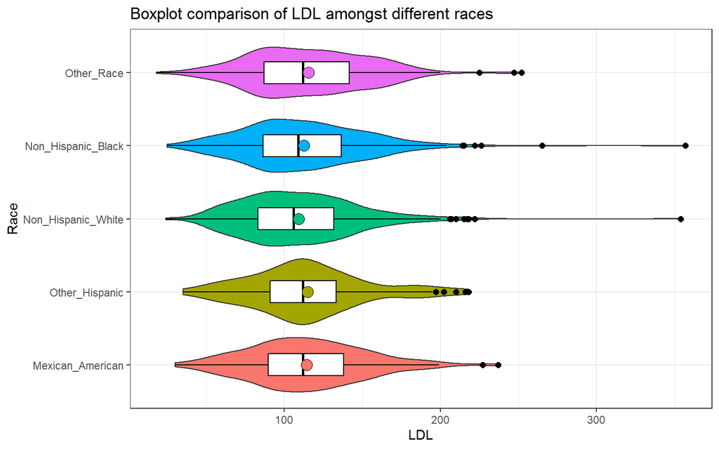

```r
ggplot(mydata_c,aes(x =race,y=ldl_chol)) +
    geom_violin(aes(fill = race)) +
    geom_boxplot(width = 0.3, outlier.size = 2,col="black") +
    stat_summary(aes(fill = race), fun = mean,
                 geom="point", pch = 21, size = 4) +
    guides(fill = "none") + coord_flip()+
  labs(y="LDL",x="Race",title="Boxplot comparison of LDL amongst different races")
```

## 6.4 Difference in mean between groups

Here we have created model 1 which is a linear model to check the difference in ldl between the races and we ran an anova on the model since we are checking differences between more than 2 groups. The anova model shows a F value of 1.61 and p of 0.16 which represents that there is no statistically detectable difference between the groups.

```r
model1<-lm(ldl_chol~race, data=mydata_c)

anova(model1)
```

|  | Df | Sum Sq | Mean Sq | F value | Pr(>F) |
| --- | --- | --- | --- | --- | --- |
| race | 4 | 9536.176 | 2384.044 | 1.618681 | 0.1670406 |
| Residuals | 1413 | 2081110.055 | 1472.831 | NA | NA |

```r
tukey1<- mydata_c %$%
    TukeyHSD(aov(ldl_chol~race),
             ordered = TRUE, conf.level = 0.90)
tukey1
```

```
  Tukey multiple comparisons of means
    90% family-wise confidence level
    factor levels have been ordered

Fit: aov(formula = ldl_chol ~ race)

$race
                                           diff         lwr       upr     p adj
Non_Hispanic_Black-Non_Hispanic_White 3.4145428  -3.3981477 10.227233 0.7314751
Mexican_American-Non_Hispanic_White   5.2292820  -2.7469207 13.205485 0.4885089
Other_Hispanic-Non_Hispanic_White     5.7475419  -3.4825840 14.977668 0.5410270
Other_Race-Non_Hispanic_White         6.3629555  -0.7049566 13.430868 0.1741222
Mexican_American-Non_Hispanic_Black   1.8147392  -6.7811396 10.410618 0.9853888
Other_Hispanic-Non_Hispanic_Black     2.3329992  -7.4375969 12.103595 0.9769015
Other_Race-Non_Hispanic_Black         2.9484127  -4.8120451 10.708870 0.8831313
Other_Hispanic-Mexican_American       0.5182599 -10.0964283 11.132948 0.9999529
Other_Race-Mexican_American           1.1336735  -7.6658585  9.933205 0.9978088
Other_Race-Other_Hispanic             0.6154135  -9.3348215 10.565649 0.9998793
```

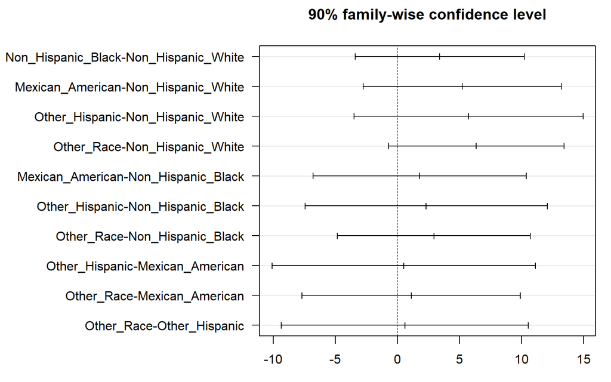

```r
par(las=1)
par(mar=c(3,17,3,1))
plot(tukey1)
```

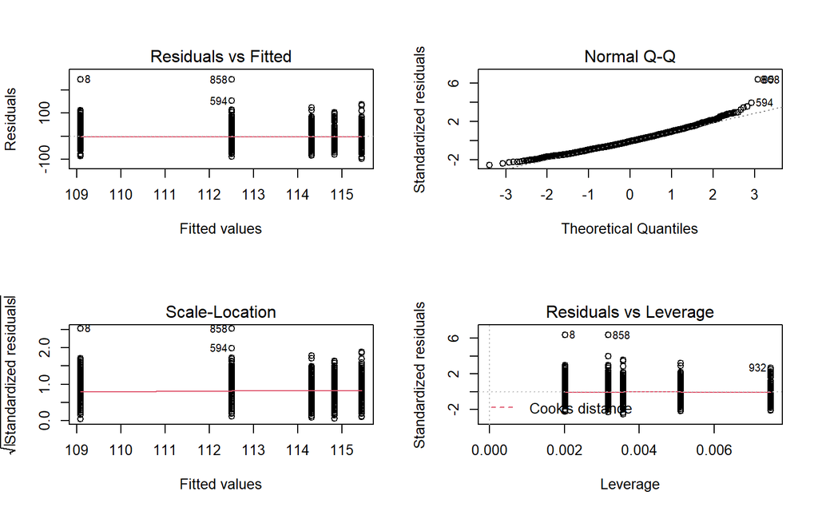

```r
par(mfrow = c(2,2)); plot(model1); par(mfrow = c(1,1))
```

## 6.6 Conclusion

ANOVA showed no significant difference in ldl between the different races. We made a TUKEY plot also and again no difference was seen between different groups.

# 7 Analysis D:Two-Way (2 x 2) Contingency Table

The two categorical variables we chose for this analysis are ‘shortness of breath’ either when hurrying on the level or walking up a slight hill and high sbp defined as sbp > median sbp.

## 7.1 Research Question

Are subjects with SBP higher than the median systolic blood pressure more prone to have shortness of breath?

## 7.2 Creating dataset

Here we have created a tibble called “temp1_ms” with the variables needed for this analysis.We converted the original variable of sbp into two levels (high/low) based on SBP> median as high and SBP< median as low.

```r
mydata <- mydata %>%
  mutate(temp1_ms = case_when( sbp < median (sbp) ~ "low",
                   TRUE ~ "high"),
           temp1_ms = factor(temp1_ms))

mosaic::favstats(sbp ~ temp1_ms, data = mydata) %>%
    kable(digits = 3)
```

| temp1_ms | min | Q1 | median | Q3 | max | mean | sd | n | missing |
| --- | --- | --- | --- | --- | --- | --- | --- | --- | --- |
| high | 128 | 134 | 142 | 154 | 228 | 146.013 | 17.078 | 746 | 0 |
| low | 78 | 110 | 116 | 122 | 126 | 114.685 | 8.793 | 672 | 0 |

## 7.3 Checking that the new data has the desired results of only values as high/low

```r
glimpse (mydata)
```

```
Rows: 1,418
Columns: 12
$ SEQN                         <dbl> 93711, 93718, 93721, 93722, 93735, 93742,~
$ gender                       <fct> Male, Male, Female, Female, Male, Male, F~
$ age                          <dbl> 56, 45, 60, 60, 52, 72, 73, 55, 60, 54, 7~
$ race                         <fct> Other_Race, Non_Hispanic_Black, Mexican_A~
$ marital_status               <fct> Married, Never_married, Married, Divorced~
$ shortness_of_breath          <fct> No, No, No, No, Yes, Yes, No, Yes, Yes, N~
$ ldl_chol                     <dbl> 156, 80, 61, 95, 56, 91, 165, 354, 25, 13~
$ sbp                          <dbl> 108, 128, 132, 116, 154, 166, 126, 154, 1~
$ dbp                          <dbl> 68, 88, 68, 68, 74, 90, 60, 74, 64, 66, 6~
$ sbp2                         <dbl> 94, 136, 136, 110, 156, 170, 130, 154, 11~
$ no_of_meals_not_homeprepared <dbl> 4, 2, 1, 7, 1, 3, 1, 0, 2, 0, 1, 3, 1, 0,~
$ temp1_ms                     <fct> low, high, high, low, high, high, low, hi~
```

## 7.4 Main analysis

Calculating the number of subjects under each category by creating a two by two table and then analyzing the data for relationship between high BP and shortness of breath.

```r
tabyl <-xtabs(~temp1_ms+shortness_of_breath,data=mydata)
tabyl
```

```
        shortness_of_breath
temp1_ms Yes  No
    high 285 461
    low  240 432
```

```r
tabyl <-xtabs(~temp1_ms+shortness_of_breath,data=mydata)
tabyl
```

```
        shortness_of_breath
temp1_ms Yes  No
    high 285 461
    low  240 432
```

```r
twobytwo(287,463,242,434,"High BP","Not high BP","Shortness of breath","No shortness of breath",conf.level=0.90)
```

[output not shown]

[output not shown]